# Individual Differences of Quantifier Interpretation

Julia Haaf

6/3/2019

```r
library("dplyr")
```

```r
library("MCMCpack")
library("LaplacesDemon")
library("rstan")
library("plotrix")
library(RColorBrewer)
library(corrplot)
```

**To Do:**

- Extend to other quantifiers (few and fewer than half).
- Look at symmetry models for fewer than half vs. more than half, and few vs. many.
- Repeat analysis for study 2 data.

## The Task (How I understand it)

In this task, participants have to evaluate whether a certain quantifier logically describes a scenario. Scenarios are percentages of, for example, apples that are green. Say, 20% of apples are green, is the statement that “most of the apples are green” true or false? Percentages are drawn from a uniform ensuring that as many trials have more than 50% as have less than 50%. The quantifiers of interest are *Few*, *Fewer than half*, *Many*, *Most* and *More than half*. The idea is that *More than half* is defined by more than 50% for everyone while *Most* may be more subjective, and it may be more than *More than half* for everyone. Additionally, we may inspect the relationship between *Many* and *More than half*, and also symmetries between mirrored quantifiers.

## Modeling Approach

I think we could use a probit regression with a participant-specific quantifier effect and a participant-specific effect of percentage used. This way we could at least assess whether *Most* is more than *More than half* by defining the quantifier effect as a contrast between the two. It could even be tested in this framework whether *More than half* is 50% for everyone.

### Model

**Disclaimer:** I have tweaked the model yesterday to accommodate the added quantifier *Many* and the model comparison I planned. Therefore, this section probably needs to be updated slightly.

Let $i$ indicate participants, $i = 1, \ldots, I$, $j$ indicate the quantifier, $j = 1, \ldots, 5$, and $k$ indicate the trial for each quantifier, $k = 1, \ldots, K_{ij}$.[^1] Then $Y_{ijk}$ is the $i$th participant’s response to the $j$th quantifier in the $k$th trial, and $Y_{ijk} = 1$ if participants indicate *true*, and $Y_{ijk} = 0$ if participant indicate *false*. Then, we may model $Y_{ijk}$ as a Bernoulli, using the probit link function on the probabilities:

$$\begin{align*}
Y_{ijk} &\sim \mbox{Bernoulli}(\pi_{ijk}),\\
\mu_{ijk} &= \Phi^{-1}(\pi_{ijk}),\\
\end{align*}$$

where the second line maps the probability space of $\pi$ onto the real space of $\mu$. We may now place a linear model on $\mu_{ijk}$:

$$\mu_{ijk} = \beta_{i0} + l_{ijk}\beta_{i1} + h_{ijk}\beta_{i2} + z_{i1} \beta_{i3} + + z_{i2} \beta_{i4} + + z_{i3} \beta_{i5} + + z_{i4} \beta_{i6} + z_{i5} \beta_{i7},$$

where $l_{ijk}$, $h_{ijk}$ and $z_{ij}$ are predictors: $l_{ijk}$ is zero for percentages above 50%, and indicates the centered percentage otherwise; $xh{ijk}$ is zero for percentages below 50%, and indicates the centered percentage otherwise, and $z_{ij}$ is an indicator function denoting the respective quantifier (e.g., $z_{i1} = 1$ for the quantifier *Fewer*, and $z_{i1} = 0$ otherwise). Parameters $\beta_{i0}$ are random intercepts, $\beta_{i1}$ are random percentage effects for percentages below 50%, $\beta_{i12}$ are random percentage effects for percentages above 50%, and $\beta_{i3}$ to $\beta_{i7}$ are random quantifier effects. For now, I will place the following priors:

$$\begin{align*}
\beta_{i0} &\sim \mbox{Normal}(0, \sigma_0^2),\\
\beta_{i1} &\sim \mbox{Normal}(\delta_1, \sigma_1^2),\\
\beta_{i2} &\sim \mbox{Normal}(\delta_2, \sigma_2^2),\\
\beta_{i3} &\sim \mbox{Normal}(\delta_3, \sigma_3^2).\\
\beta_{i4} &\sim \mbox{Normal}(\delta_4, \sigma_4^2).\\
\beta_{i5} &\sim \mbox{Normal}(\delta_5, \sigma_5^2).\\
\beta_{i6} &\sim \mbox{Normal}(\delta_6, \sigma_6^2).\\
\beta_{i7} &\sim \mbox{Normal}(\delta_7, \sigma_7^2).\\
\end{align*}$$

**Needed:** Proper description of prior settings.

## Study 1

### Data

```r
exclude <- c(0, 1, 5, 18, 32, 39, 49, 52, 53, 58, 62, 81, 82, 83, 85, 86, 87, 27, 76)
 # 0,1,5,39,18,32,49,52,53,58,62,81,82,83,85,86,87,76
exclude2 <- c(27, 76)

dat <- read.csv("data/exp1-replication-trials.csv")
head(dat)
```

```
##   workerid       A         B percent read_and_decide_time  quant read_time_one
## 1        0 "glerb"  "fizzda"      20                 3702  "All"           183
## 2        0 "thonk" "krangly"      82                  433 "Some"           264
## 3        0 "slarm" "briddle"      11                  287 "None"           216
## 4        0 "klong"   "nooty"      62                   16  "All"            48
## 5        0 "dring"   "larfy"      28                  384 "None"           113
## 6        0 "floom" "plerful"      92                  126 "Some"           104
##   response
## 1    false
## 2    false
## 3     true
## 4     true
## 5    false
## 6    false
```

```r
nrow(dat)
```

```
## [1] 23220
```

```r
# Exclusion based on Sonia's code
## Participant-level
dat <- subset(dat, !(workerid %in% exclude))
nrow(dat)
```

```
## [1] 18318
```

```r
## Trial-level
dat <- subset(dat, read_and_decide_time > 300)
dat <- subset(dat, read_and_decide_time < 2500)
nrow(dat)
```

```
## [1] 17233
```

```r
table(dat$quant, dat$workerid)[, 1]
```

```
##             "All"             "Few" "Fewer than half"            "Many"
##                 2                48                48                50
##  "More than half"            "Most"            "None"            "Some"
##                50                50                 3                 1
```

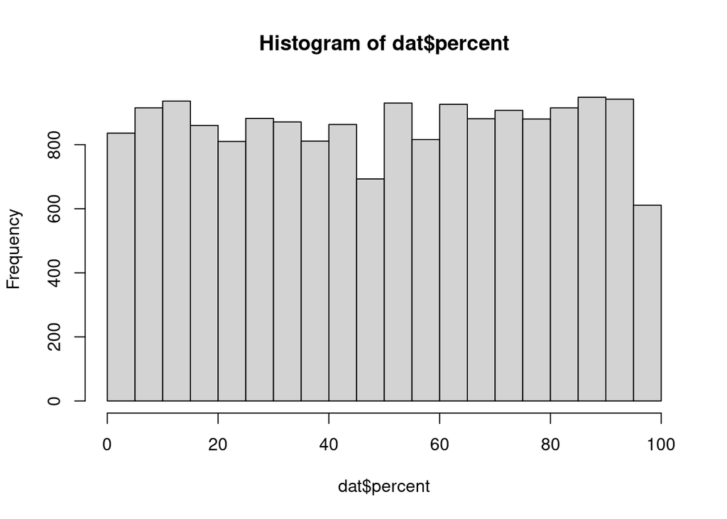

```r
hist(dat$percent)
```

```r
table(dat$percent>50)
```

```
##
## FALSE  TRUE
##  8477  8756
```

```r
table(dat$response, dat$quant)
```

```
##
##         "All" "Few" "Fewer than half" "Many" "More than half" "Most" "None"
##   false    89  2034              1798   1419             1724   1798    132
##   true     10  1277              1605   1943             1726   1606      9
##
##         "Some"
##   false     13
##   true      50
```

```r
dat$qq <- as.numeric(factor(dat$quant))

dat <- subset(dat, qq %in% 2:6)
prop <- tapply(as.numeric(factor(dat$response)) - 1, list(dat$percent, dat$qq), mean, na.rm = T)
```

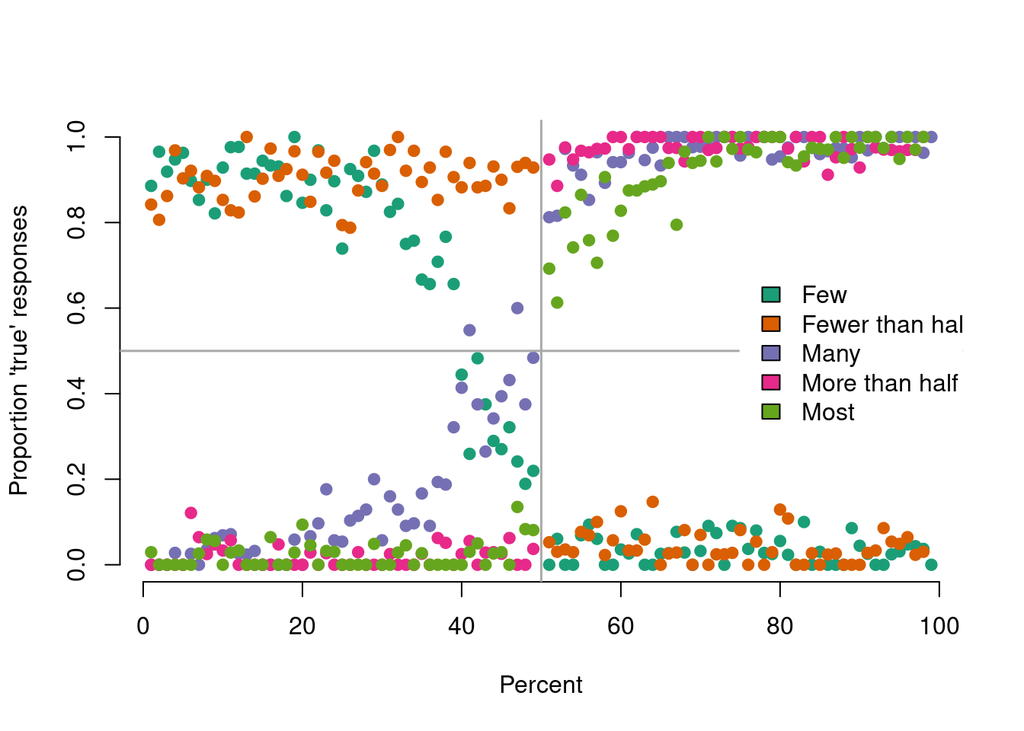

```r
qcols <- brewer.pal(5, "Dark2")

matplot(as.numeric(rownames(prop)), prop
        , pch = 19, col = qcols
        , xlab = "Percent", ylab = "Proportion 'true' responses"
        , frame.plot = F)
abline(v = 50, lwd = 1.5, col = "darkgrey")
abline(h = .50, lwd = 1.5, col = "darkgrey")
legend(75, .7, legend = c("Few", "Fewer than half", "Many", "More than half", "Most")
       , fill = qcols, bg = "white", box.col = "white")
```

I now recode the responses to correspond to the expected direction of response. I will therefore flip TRUE and FALSE responses for the quantifiers *few* and *fewer than half*.

```r
dat$resp <- case_when(
  dat$qq %in% 4:6 ~ as.numeric(factor(dat$response)) - 1,
  dat$qq %in% 2:3 ~ -as.numeric(factor(dat$response)) + 2
)
```

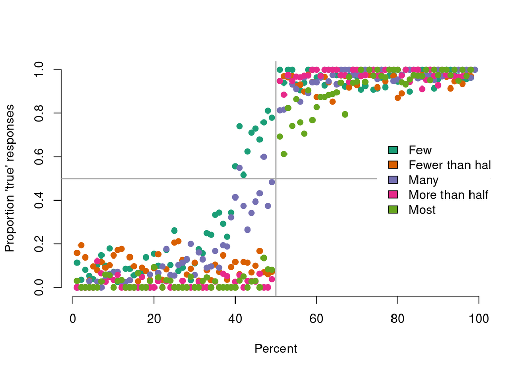

```r
prop <- tapply(dat$resp, list(dat$percent, dat$qq), mean, na.rm = T)
qcols <- brewer.pal(5, "Dark2")

matplot(as.numeric(rownames(prop)), prop
        , pch = 19, col = qcols
        , xlab = "Percent", ylab = "Proportion 'true' responses"
        , frame.plot = F)
abline(v = 50, lwd = 1.5, col = "darkgrey")
abline(h = .50, lwd = 1.5, col = "darkgrey")
legend(75, .7, legend = c("Few", "Fewer than half", "Many", "More than half", "Most")
       , fill = qcols, bg = "white", box.col = "white")
```

### Estimation

#### Priors

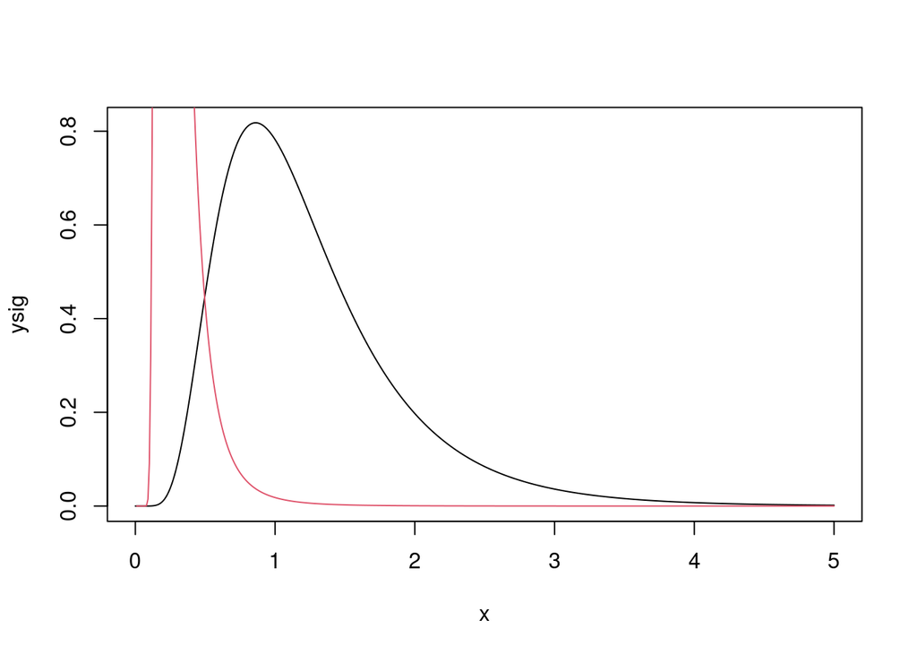

```r
x <- seq(0, 5, .01)
ysig <- dlnorm(x, .1, .5)
ysig2 <- 2 * x * dinvgamma(x^2, 2, .1)
plot(x, ysig, type = "l")
lines(x, ysig2, col = 2)
```

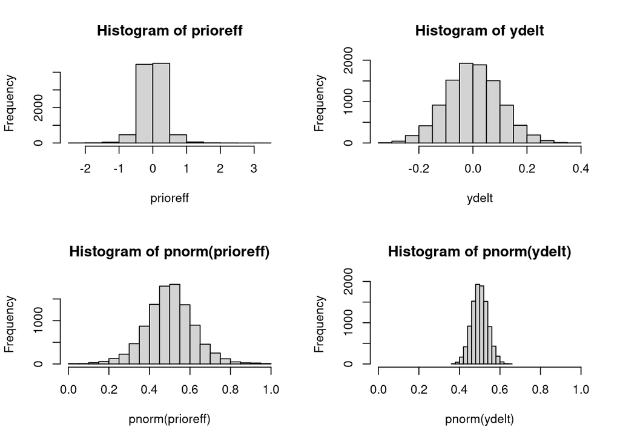

```r
ydelt <- rnorm(x, 0, .1)

M <- 10000
ysig2 <- rinvgamma(M, 2, .1)
ydelt <- rnorm(M, 0, .1)

prioreff <- rnorm(M, ydelt, sqrt(ysig2))

layout(matrix(1:4, ncol = 2, byrow = T))
hist(prioreff)
hist(ydelt)
hist(pnorm(prioreff), xlim = c(0, 1))
hist(pnorm(ydelt), xlim = c(0, 1))
```

#### Model

```stan
data {
  int<lower=1> D;                     // #Dimensions of the model
  int<lower=0> N;                     // #Observations
  int<lower=1> I;                     // #Participants
  int<lower=0,upper=1> y[N];          // Data 0,1
  vector[N] cperc;                    // Centered Percentages
  int<lower=1,upper=I> sub[N];        // participant vector
  int<lower=0,upper=1> few[N];      // Few
  int<lower=0,upper=1> fewer[N];      // Fewer than half
  int<lower=0,upper=1> many[N];      // Many
  int<lower=0,upper=1> more[N];      // More than half
  int<lower=0,upper=1> most[N];      // Most
  int<lower=0,upper=1> above[N];      // Above 50 percent?
}

parameters {
  real delta[D];                      // Means of betas
  real<lower=0> sigma2[D];             // variance of betas
  vector[D] beta[I];                  // vectors of betas
  real gamma[D];                      // Means of alphas
  real<lower=0> sigma2alpha[D];       // variance of alphas
  vector<lower=0>[D] alpha[I];                  // vectors of alphas
}

transformed parameters {
  real<lower=0> sigma[D];
  real<lower=0> sigmaalpha[D];
  sigma = sqrt(sigma2);
  sigmaalpha = sqrt(sigma2alpha);
}

model {
  vector[N] mu;
  delta ~ normal(0, 5);
  sigma2 ~ inv_gamma(2, .1);
  gamma ~ normal(0, 5);
  sigma2alpha ~ inv_gamma(2, .1);
  for (i in 1:I)
    beta[i] ~ normal(delta, sigma);
  for (i in 1:I)
    alpha[i] ~ lognormal(gamma, sigmaalpha);
  for (n in 1:N)
    mu[n] = few[n] * (cperc[n] - beta[sub[n], 1]) / alpha[sub[n], 1] + fewer[n] * (cperc[n] - beta[sub[n], 2]) / alpha[sub[n], 2] + many[n] * (cperc[n] - beta[sub[n], 3]) / alpha[sub[n], 3] + more[n] * (cperc[n] - beta[sub[n], 4]) / alpha[sub[n], 4] + most[n] * (cperc[n] - beta[sub[n], 5]) / alpha[sub[n], 5];
  y ~ bernoulli_logit(mu);
}
```

```r
getDat <- function(dat){
  # dat <- subset(dat, qq %in% 4:6)

  D <- 5
  N <- nrow(dat)
  I <- length(unique(dat$workerid))

  y <- dat$resp
  cperc <- (dat$percent - 50) / 100
  sub <- as.numeric(factor(dat$workerid))
  few <- ifelse(dat$qq == 2, 1, 0)
  fewer <- ifelse(dat$qq == 3, 1, 0)
  many <- ifelse(dat$qq == 4, 1, 0)
  more <- ifelse(dat$qq == 5, 1, 0)
  most <- ifelse(dat$qq == 6, 1, 0)
  above <- as.numeric(cperc > 0)

  # res <- glm(y ~ cperc + few + fewer + many + more + most, family = binomial(link = "probit"),
  #   data = dat)

  standat <- list(D = D, N = N, I = I, y = y, cperc = cperc, sub = sub,
                  few = few, fewer = fewer, many = many, more = more, most = most
                  , above = above)
  return(standat)
}

myRunner <- function(standat, iter = 1000, warmup = 400, mod, nchains = 4, ...){
  inits <- function(...){
    list(delta = runif(standat$D, -.5, .5)
         , sigma2 = runif(standat$D, 1, 1.5)
         , beta = matrix(runif(standat$I * standat$D, -1, 1), nrow = standat$I, ncol = standat$D)
         , gamma = runif(standat$D, .1, 1)
         , sigma2alpha = runif(standat$D, 1, 1.5)
         , alpha = matrix(runif(standat$I * standat$D, .1, 1), nrow = standat$I, ncol = standat$D))
  }
  # inits <- list(c1 = inits)
  fit <- sampling(mod, verbose=T,
                  data = standat,
                  iter = iter,
                  warmup = warmup,
                  chains = nchains,
                  cores = nchains,
                  # init = lapply(1:4, inits),
                  pars = c("delta", "gamma", "beta", "alpha", "sigma2", "sigma2alpha")
                  , ...)
  return(fit)}

predat <- getDat(dat)
```

```r
rerun <- T
logmodfit <- myRunner(predat
                      , iter = 5000
                      , warmup = 1000
                      , mod = logmod
                      , control = list(adapt_delta = .975, max_treedepth = 15)
                      , nchains = 4)
save(logmodfit, file = "outstudy1b.rda")
```

```r
load("outstudy1b.rda")
```

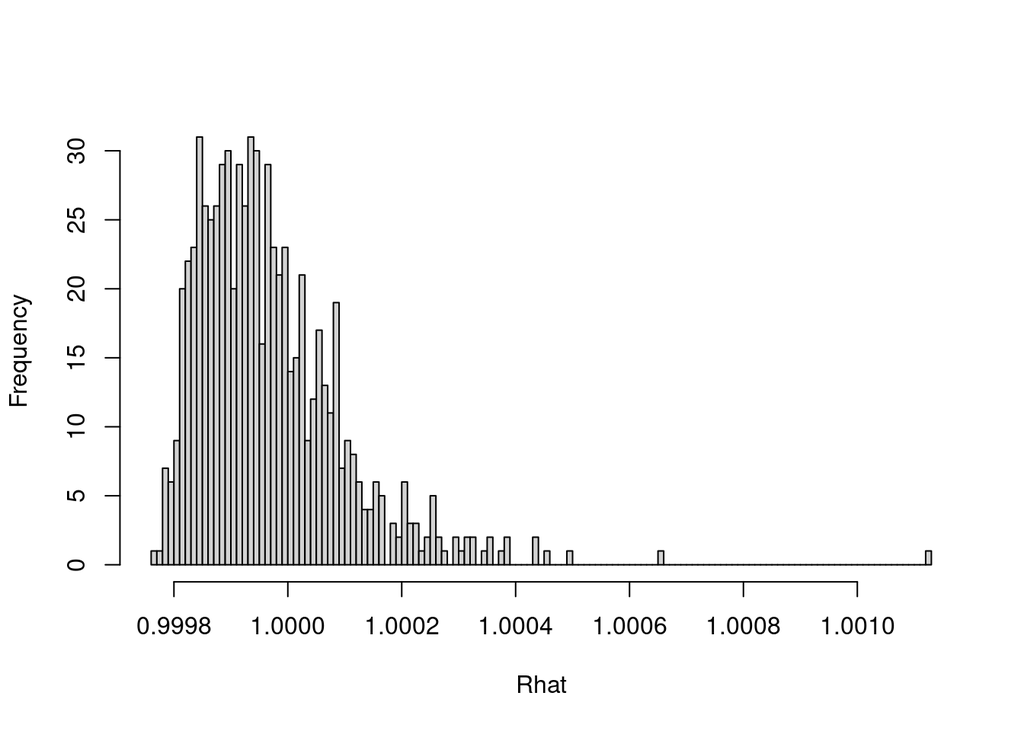

```r
hist(summary(logmodfit)$summary[,"Rhat"]
     , breaks = 100
     , main = ""
     , xlab =  "Rhat")
```

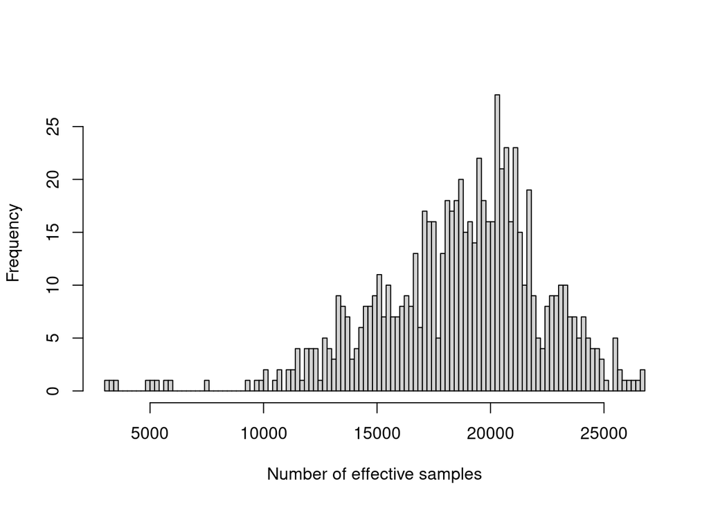

```r
hist(summary(logmodfit)$summary[,"n_eff"]
     , breaks = 100
     , main = ""
     , xlab =  "Number of effective samples")
```

### Results

```r
pEst <- as.matrix(logmodfit)
dim(pEst)
```

```
## [1] 16000   731
```

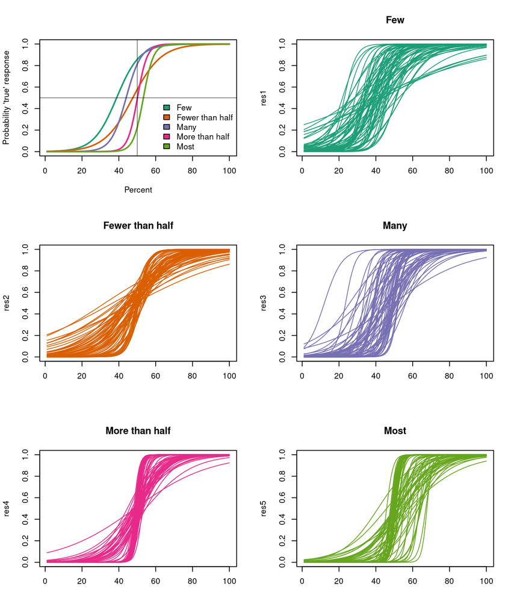

```r
pMeans <- colMeans(pEst)

I <- predat$I
pdelta1 <- pMeans[1]
pdelta2 <- pMeans[2]
pdelta3 <- pMeans[3]
pdelta4 <- pMeans[4]
pdelta5 <- pMeans[5]
pgamma1 <- pMeans[6]
pgamma2 <- pMeans[7]
pgamma3 <- pMeans[8]
pgamma4 <- pMeans[9]
pgamma5 <- pMeans[10]
pbeta1 <- pMeans[10 + 1:I]
pbeta2 <- pMeans[10 + I + 1:I]
pbeta3 <- pMeans[10 + 2 * I + 1:I]
pbeta4 <- pMeans[10 + 3 * I + 1:I]
pbeta5 <- pMeans[10 + 4 * I + 1:I]
palpha1 <- pMeans[10 + 5 * I + 1:I]
palpha2 <- pMeans[10 + 6 * I + 1:I]
palpha3 <- pMeans[10 + 7 * I + 1:I]
palpha4 <- pMeans[10 + 8 * I + 1:I]
palpha5 <- pMeans[10 + 9 * I + 1:I]

cperc <- (1:100 - 50)/100
curve.calc <- function(x, p = cperc){
  a <- (p - x[1])/x[2]
  exp(a)/(exp(a) + 1)
}

pps1 <- curve.calc(c(pdelta1, exp(pgamma1)))
pps2 <- curve.calc(c(pdelta2, exp(pgamma2)))
pps3 <- curve.calc(c(pdelta3, exp(pgamma3)))
pps4 <- curve.calc(c(pdelta4, exp(pgamma4)))
pps5 <- curve.calc(c(pdelta5, exp(pgamma5)))

layout(matrix(1:6, ncol = 2, byrow = T))

plot(1:100, pps1, type = "l", lwd = 2, col = qcols[1], ylim = c(0,1)
     , ylab = "Probability 'true' response", xlab = "Percent")
lines(1:100, pps2, lwd = 2, col = qcols[2])
lines(1:100, pps3, lwd = 2, col = qcols[3])
lines(1:100, pps4, lwd = 2, col = qcols[4])
lines(1:100, pps5, lwd = 2, col = qcols[5])
abline(h = .5, col = adjustcolor(1, .5))
abline(v = 50, col = adjustcolor(1, .5))
legend("bottomright", legend = c("Few", "Fewer than half", "Many", "More than half", "Most")
       , fill = qcols, bty = "n")

res1 <- apply(cbind(pbeta1, palpha1), 1, curve.calc)
matplot(res1, type = "l", lty = 1, col = qcols[1], main =  "Few")
res2 <- apply(cbind(pbeta2, palpha2), 1, curve.calc)
matplot(res2, type = "l", lty = 1, col = qcols[2], main =  "Fewer than half")
res3 <- apply(cbind(pbeta3, palpha3), 1, curve.calc)
matplot(res3, type = "l", lty = 1, col = qcols[3], main =  "Many")
res4 <- apply(cbind(pbeta4, palpha4), 1, curve.calc)
matplot(res4, type = "l", lty = 1, col = qcols[4], main = "More than half")
res5 <- apply(cbind(pbeta5, palpha5), 1, curve.calc)
matplot(res5, type = "l", lty = 1, col = qcols[5], main =  "Most")
```

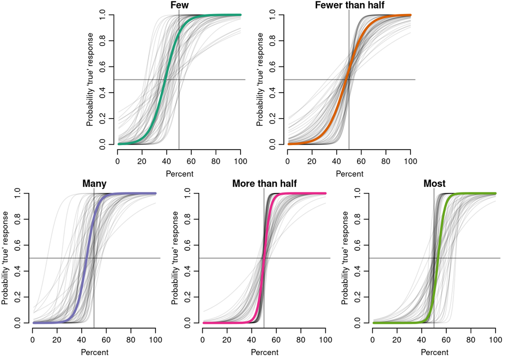

```r
layout(matrix(c(0, 1,1, 2,2, 0, 3,3,4,4,5,5), nrow = 2, byrow = T))
par(mgp = c(2, .7, 0), mar = c(3,3,1,1))

matplot(1:100, res1, type = "l", lty = 1, main = "Few", ylim = c(0,1), col = adjustcolor(1, .1)
        , ylab = "Probability 'true' response", xlab = "Percent", frame.plot = F)
abline(h = .5, col = adjustcolor(1, .5))
abline(v = 50, col = adjustcolor(1, .5))
lines(1:100, pps1, lwd = 3, col = qcols[1])

matplot(1:100, res2, type = "l", lty = 1, main = "Fewer than half", ylim = c(0,1), col = adjustcolor(1, .1)
        , ylab = "Probability 'true' response", xlab = "Percent", frame.plot = F)
abline(h = .5, col = adjustcolor(1, .5))
abline(v = 50, col = adjustcolor(1, .5))
lines(1:100, pps2, lwd = 3, col = qcols[2])

matplot(1:100, res3, type = "l", lty = 1, main = "Many", ylim = c(0,1), col = adjustcolor(1, .1)
        , ylab = "Probability 'true' response", xlab = "Percent", frame.plot = F)
abline(h = .5, col = adjustcolor(1, .5))
abline(v = 50, col = adjustcolor(1, .5))
lines(1:100, pps3, lwd = 3, col = qcols[3])

matplot(1:100, res4, type = "l", lty = 1, main = "More than half", ylim = c(0,1), col = adjustcolor(1, .1)
        , ylab = "Probability 'true' response", xlab = "Percent", frame.plot = F)
abline(h = .5, col = adjustcolor(1, .5))
abline(v = 50, col = adjustcolor(1, .5))
lines(1:100, pps4, lwd = 3, col = qcols[4])

matplot(1:100, res5, type = "l", lty = 1, main = "Most", ylim = c(0,1), col = adjustcolor(1, .1)
        , ylab = "Probability 'true' response", xlab = "Percent", frame.plot = F)
abline(h = .5, col = adjustcolor(1, .5))
abline(v = 50, col = adjustcolor(1, .5))
lines(1:100, pps5, lwd = 3, col = qcols[5])
```

- Now for the thresholds.

```r
(M1 <- cor(cbind("few" = pbeta1, "fewer" = pbeta2, "many" = pbeta3, "more" = pbeta4, "most" = pbeta5)))
```

```
##               few         fewer        many        more          most
## few    1.00000000  0.0415366815  0.21386473 -0.02801141 -0.1477814115
## fewer  0.04153668  1.0000000000 -0.14481465 -0.08247426 -0.0006716694
## many   0.21386473 -0.1448146514  1.00000000 -0.05407848  0.2117404339
## more  -0.02801141 -0.0824742602 -0.05407848  1.00000000  0.2174862002
## most  -0.14778141 -0.0006716694  0.21174043  0.21748620  1.0000000000
```

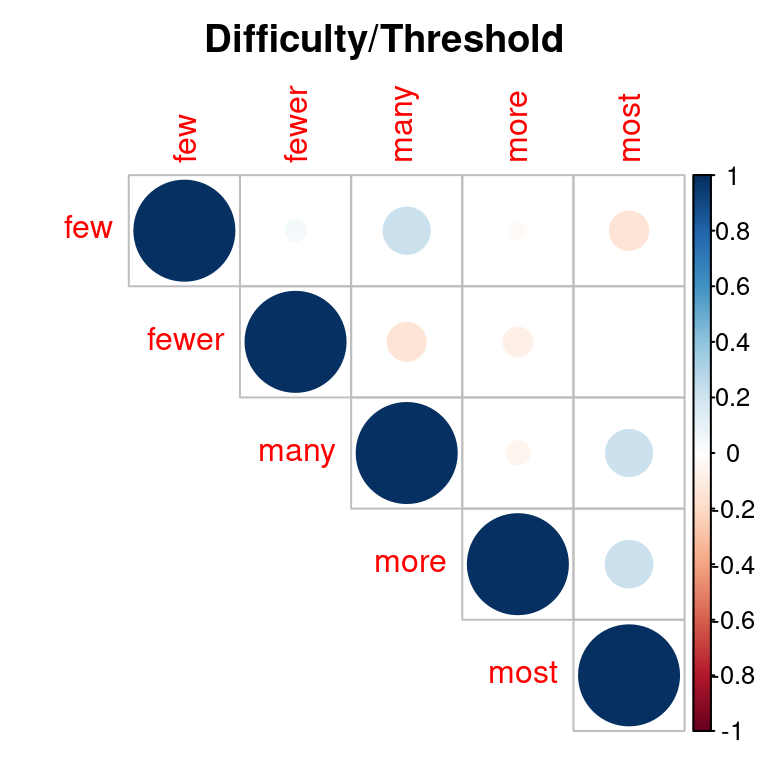

```r
corrplot(M1, type = "upper", title = "Difficulty/Threshold", mar = c(0,0,2,0))
```

```r
sds1 <- apply(cbind("few" = pbeta1, "fewer" = pbeta2, "many" = pbeta3, "more" = pbeta4, "most" = pbeta5), 2, sd)
means1 <- apply(cbind("few" = pbeta1, "fewer" = pbeta2, "many" = pbeta3, "more" = pbeta4, "most" = pbeta5), 2, mean)

(M2 <- cor(cbind("few" = palpha1, "fewer" = palpha2, "many" = palpha3, "more" = palpha4, "most" = palpha5)))
```

```
##             few     fewer      many      more      most
## few   1.0000000 0.6709607 0.4121831 0.3146882 0.6444366
## fewer 0.6709607 1.0000000 0.3700354 0.3079532 0.4709916
## many  0.4121831 0.3700354 1.0000000 0.2726726 0.3912297
## more  0.3146882 0.3079532 0.2726726 1.0000000 0.2818914
## most  0.6444366 0.4709916 0.3912297 0.2818914 1.0000000
```

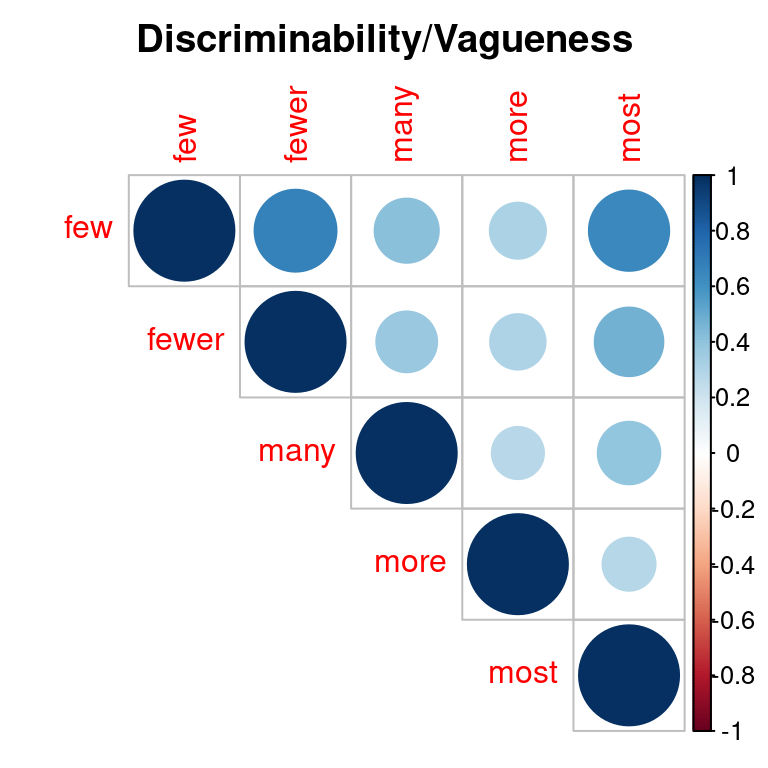

```r
corrplot(M2, type = "upper", title = "Discriminability/Vagueness", mar = c(0,0,2,0))
```

```r
sds2 <- apply(cbind("few" = palpha1, "fewer" = palpha2, "many" = palpha3, "more" = palpha4, "most" = palpha5), 2, sd)
means2 <- apply(cbind("few" = palpha1, "fewer" = palpha2, "many" = palpha3, "more" = palpha4, "most" = palpha5), 2, mean)
```

#### Comparing “More than half” and “Most”

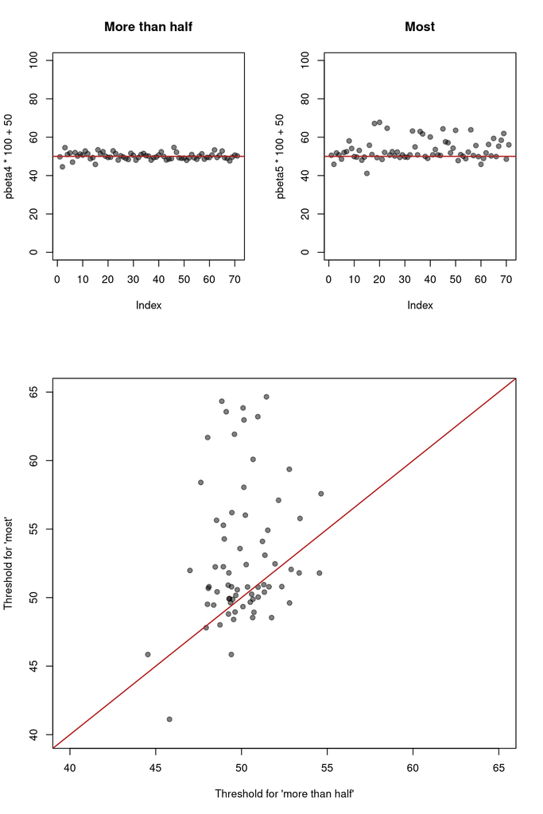

```r
layout(matrix(c(1,2,3,3), ncol = 2, byrow = T), heights = c(.4, .6))

plot(pbeta4 * 100 + 50, pch = 19, col = adjustcolor(1, .5), main = "More than half", ylim = c(0, 100))
abline(h = 50, lwd = 1.5, col = "firebrick")
plot(pbeta5 * 100 + 50, pch = 19, col = adjustcolor(1, .5), main = "Most", ylim = c(0, 100))
abline(h = 50, lwd = 1.5, col = "firebrick")

plot(pbeta4 * 100 + 50, pbeta5 * 100 + 50
     , pch = 19, col = adjustcolor(1, .5)
     , ylab = "Threshold for 'most'"
     , xlab = "Threshold for 'more than half'"
     , xlim = c(40, 65)
     , ylim = c(40, 65)
     )
abline(0, 1, lwd = 1.5, col = "firebrick")
```

```r
mbeta4 <- pEst[,10 + 3 * I + 1:I]
mbeta5 <- pEst[,10 + 4 * I + 1:I]
mdiff <- mbeta4
for(i in 1:ncol(mdiff)){
  mdiff[,i] <- apply(cbind(mbeta4[,i], mbeta5[,i]), 1, function(x) x[2] - x[1])
}
pCIs <- apply(mdiff, 2, quantile, probs = c(.025, .975))
pThresh <- apply(mdiff, 2, mean)
```

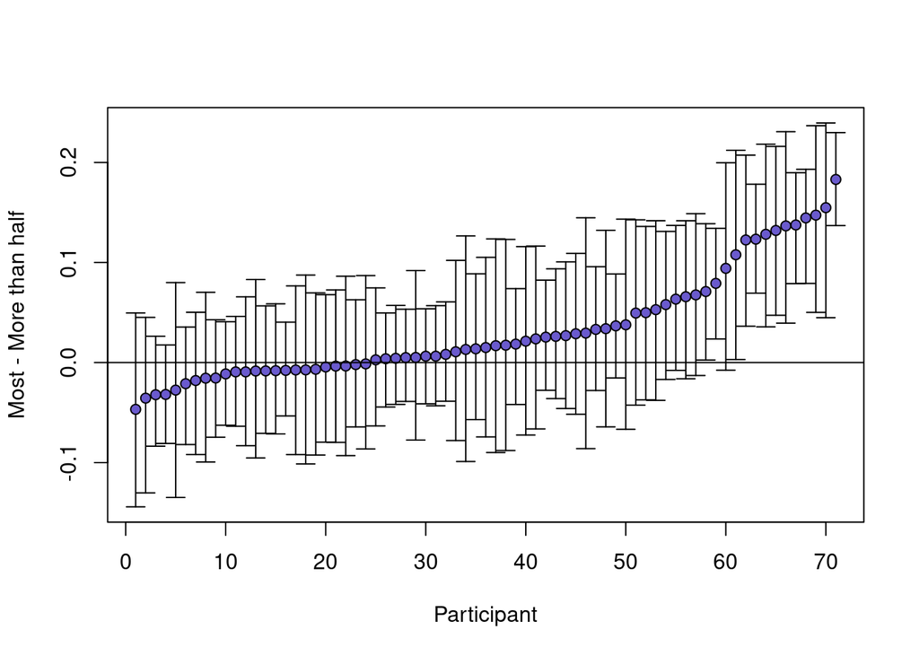

```r
indord <- order(pThresh)
plotCI(1:I, pThresh[indord]
       , li = pCIs[1, indord], ui = pCIs[2, indord]
       , pch = 21, pt.bg = "slateblue"
       , ylab = "Most - More than half"
       , xlab = "Participant")
abline(h = 0)
```

```r
## Prior probability
M <- 100000
s2 <- rinvgamma(M, 2, .1)
beta4 <- rnorm(M, 0, .1)

prioreff <- exp(pnorm(0, beta4, sqrt(s2), lower.tail = T, log.p = T) * I)
priorneg <- mean(prioreff)

## Posterior Probability
targ <- mdiff
good <- targ < 0 #evaluate their sign
all.good <- apply(good, 1, mean) #evaluate how often all theta estimates are postitive
postneg <- mean(all.good == 1) #Posterior probability of all theta_i being positive

# priorneg
# postneg

bfmomo <- postneg/priorneg
```

#### Comparing “More than half” and “Many”

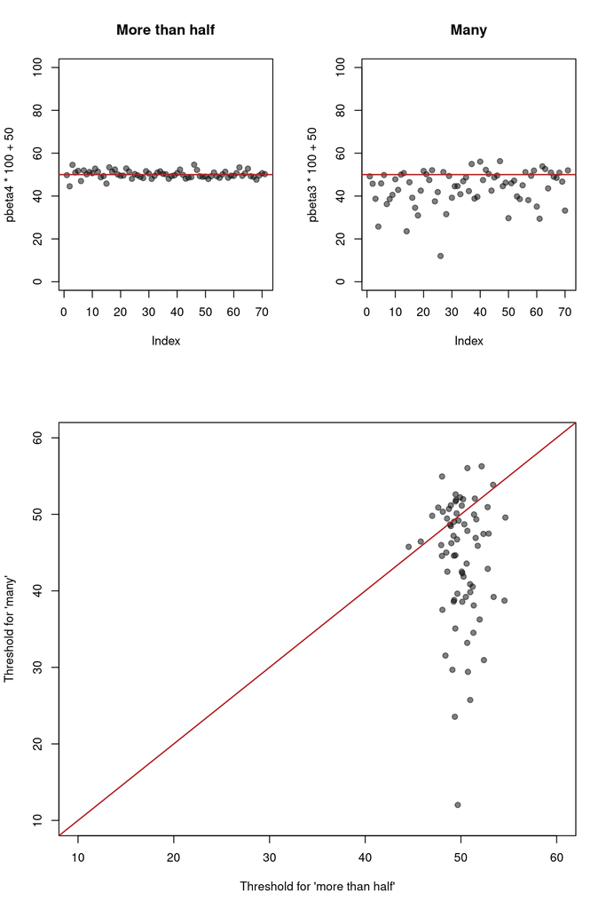

```r
layout(matrix(c(1,2,3,3), ncol = 2, byrow = T), heights = c(.4, .6))

plot(pbeta4 * 100 + 50, pch = 19, col = adjustcolor(1, .5), main = "More than half", ylim = c(0, 100))
abline(h = 50, lwd = 1.5, col = "firebrick")
plot(pbeta3 * 100 + 50, pch = 19, col = adjustcolor(1, .5), main = "Many", ylim = c(0, 100))
abline(h = 50, lwd = 1.5, col = "firebrick")

plot(pbeta4 * 100 + 50, pbeta3 * 100 + 50
     , pch = 19, col = adjustcolor(1, .5)
     , ylab = "Threshold for 'many'"
     , xlab = "Threshold for 'more than half'"
     , xlim = c(10, 60)
     , ylim = c(10, 60)
     )
abline(0, 1, lwd = 1.5, col = "firebrick")
```

```r
mbeta4 <- pEst[,10 + 3 * I + 1:I]
mbeta3 <- pEst[,10 + 2 * I + 1:I]
mdiffmany <- mbeta4
for(i in 1:ncol(mdiff)){
  mdiffmany[,i] <- apply(cbind(mbeta3[,i], mbeta4[,i]), 1, function(x) x[2] - x[1])
}
pCIs <- apply(mdiffmany, 2, quantile, probs = c(.025, .975))
pThresh <- apply(mdiffmany, 2, mean)
```

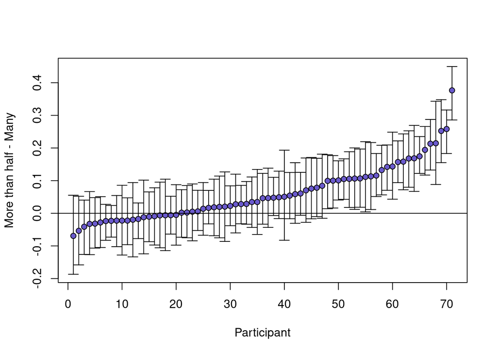

```r
indord <- order(pThresh)
plotCI(1:I, pThresh[indord]
       , li = pCIs[1, indord], ui = pCIs[2, indord]
       , pch = 21, pt.bg = "slateblue"
       , ylab = "More than half - Many"
       , xlab = "Participant")
abline(h = 0)
```

**Bayes factor assessing whether *Many* is less than *More than half* for everyone.**

```r
## Prior probability
M <- 100000
s2 <- rinvgamma(M, 2, .1)
beta3 <- rnorm(M, 0, .1)

prioreff <- exp(pnorm(0, beta3, sqrt(s2), lower.tail = T, log.p = T) * I)
priorneg <- mean(prioreff)

## Posterior Probability
targ <- mdiffmany
good <- targ > 0 #evaluate their sign
all.good <- apply(good, 1, mean) #evaluate how often all theta estimates are postitive
postneg <- mean(all.good == 1) #Posterior probability of all theta_i being positive

# priorneg
postneg
```

```
## [1] 0
```

```r
bfmamo <- postneg/priorneg
```

## Additional Analyses

### Simulation

Simple rule-based responding by setting a fixed boundary. The lines represent different levels of perceptual noise. Where this source of noise would come from in our experiment is completely unclear to me.

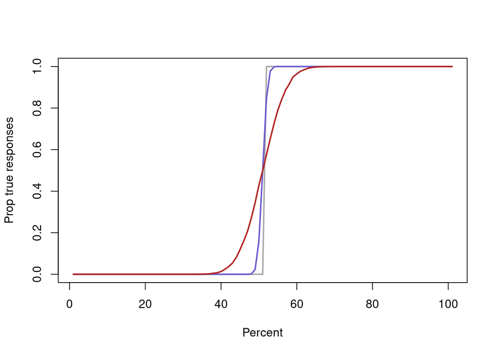

```r
## One response
resp <- function(p) rbinom(length(p), 1, p)

## Curve simulation
sim.curve.rule <- function(boundary, perc.noise){
  x <- seq(0, 1, .01)
  xmat <- matrix(rep(x, 10000), nrow = length(x))
  res <- apply(xmat, 1, rule.resp, noise = perc.noise, boundary = boundary)
  return(colMeans(res))
}

## Response rules

## Deliberate rule-based respongind is perfect responding
rule.resp <- function(x, boundary, noise = 0){
  x.perc <- rnorm(length(x), x, noise)
  p <- ifelse(x.perc > boundary, 1, 0)
  resp(p)
}

plot(sim.curve.rule(0.5, 0), type = "l", lwd = 2, col = "darkgray", ylab = "Prop true responses", xlab = "Percent")
lines(sim.curve.rule(0.5, 0.01), col = "slateblue", lwd = 2) # 1% perceptual noise
lines(sim.curve.rule(0.5, 0.05), col = "firebrick", lwd = 2) # 5% perceptual noise
```

**Negation** adds error/noise to the probability of responding correctly. This can either be uniform (makes most sense to me) or a function of the distance from the boundary.

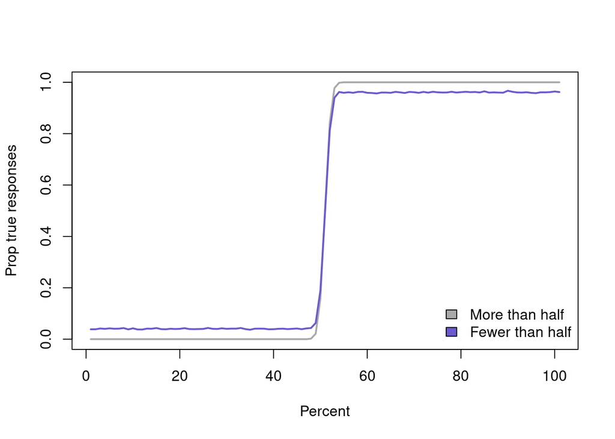

```r
## One response
resp <- function(p) rbinom(length(p), 1, p)

## Curve simulation
sim.curve.neg <- function(boundary, perc.noise, neg.noise, neg){
  x <- seq(0, 1, .01)
  xmat <- matrix(rep(x, 10000), nrow = length(x))
  res <- apply(xmat, 1, rule.resp.neg
               , noise = perc.noise
               , boundary = boundary
               , neg.noise = neg.noise
               , neg = neg)
  return(colMeans(res))
}

## Response rules

## Deliberate rule-based respongind is perfect responding
rule.resp.neg <- function(x, boundary, noise = 0, neg.noise = 0.05, neg = T){
  x.perc <- rnorm(length(x), x, noise)
  p <- ifelse(x.perc > boundary, 1, 0)
  if(neg == T){
    p.noise <- rnorm(length(p), p, neg.noise)
    p <- ifelse(p.noise>1, 1, ifelse(p.noise<0, 0, p.noise))
  }
  resp(p)
}

plot(sim.curve.neg(0.5, 0.01, 0, F), type = "l", lwd = 2, col = "darkgray", ylab = "Prop true responses", xlab = "Percent")
lines(sim.curve.neg(0.5, 0.01, .1, T), col = "slateblue", lwd = 2) # 1% perceptual noise
legend("bottomright", legend = c("More than half", "Fewer than half"), fill = c("darkgray", "slateblue"), bty = "n")
```

I had a bit of an issue finding a good way of adding noise as a function of distance from boundary. Have to play a bit more.

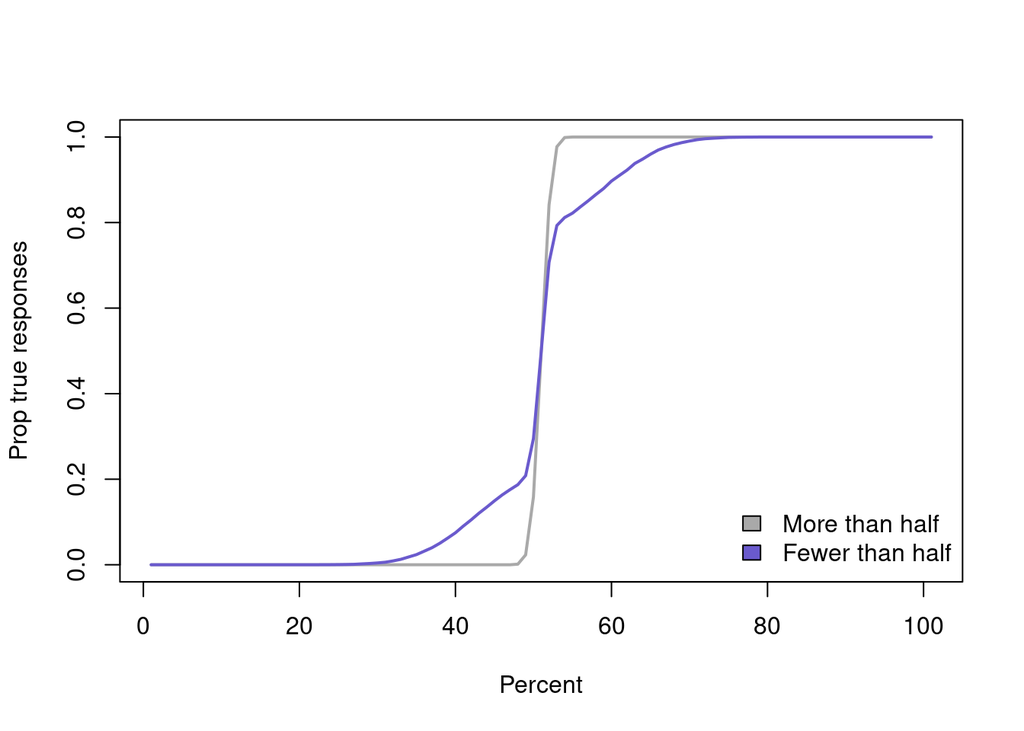

```r
## One response
resp <- function(p) rbinom(length(p), 1, p)

## Curve simulation
sim.curve.neg <- function(boundary, perc.noise, neg.noise, neg){
  x <- seq(0, 1, .01)
  xmat <- matrix(rep(x, 100000), nrow = length(x))
  res <- apply(xmat, 1, rule.resp.neg
               , noise = perc.noise
               , boundary = boundary
               , neg.noise = neg.noise
               , neg = neg)
  return(colMeans(res))
}

## Response rules

## Deliberate rule-based respongind is perfect responding
rule.resp.neg <- function(x, boundary, noise = 0, neg.noise = 0.2, neg = T){
  x.perc <- rnorm(length(x), x, noise)
  p <- ifelse(x.perc > boundary, 1, 0)
  z.noise <- dnorm(qnorm(x), sd = neg.noise) * neg.noise
  dir.noise <- sample(c(-1, 1), size = length(x), replace = T)
  if(neg == T){
    p.noise <- p + z.noise * dir.noise
    p <- ifelse(p.noise>1, 1, ifelse(p.noise<0, 0, p.noise))
  }
  resp(p)
}

plot(sim.curve.neg(0.5, 0.01, 0, F), type = "l", lwd = 2, col = "darkgray", ylab = "Prop true responses", xlab = "Percent")
lines(sim.curve.neg(0.5, 0.01, .2, T), col = "slateblue", lwd = 2) # 1% perceptual noise
legend("bottomright", legend = c("More than half", "Fewer than half"), fill = c("darkgray", "slateblue"), bty = "n")
```

**Vague quantifier** implies sampling the boundary from a distribution for each trial new.

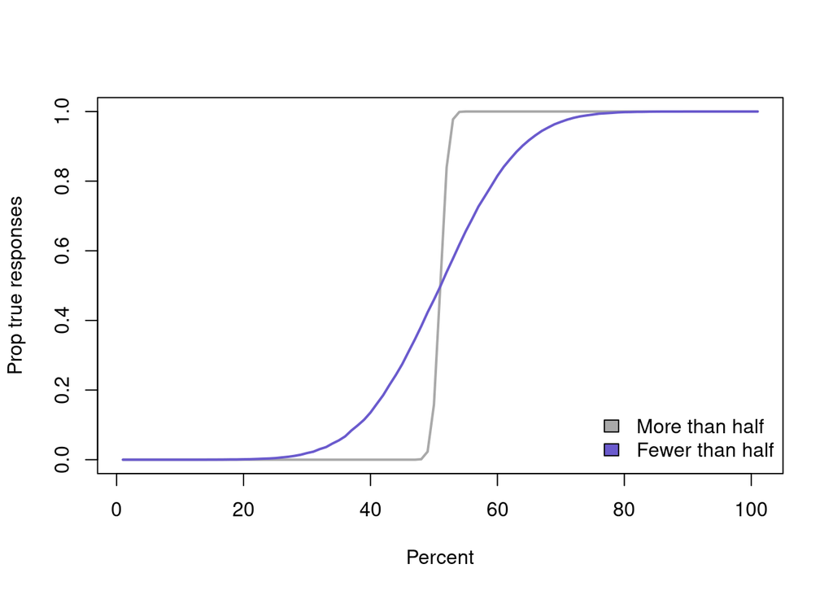

```r
## One response
resp <- function(p) rbinom(length(p), 1, p)

## Curve simulation
sim.curve.vague <- function(boundary, perc.noise, bound.noise){
  x <- seq(0, 1, .01)
  xmat <- matrix(rep(x, 100000), nrow = length(x))
  res <- apply(xmat, 1, resp.vague
               , noise = perc.noise
               , boundary = boundary
               , bound.noise = bound.noise)
  return(colMeans(res))
}

## Response rules

## Deliberate rule-based respongind is perfect responding
resp.vague <- function(x, boundary, noise = 0, bound.noise = 0.2){
  x.perc <- rnorm(length(x), x, noise)
  bound.perc <- rnorm(length(x), boundary, bound.noise)
  p <- ifelse(x.perc > bound.perc, 1, 0)
  resp(p)
}

plot(sim.curve.vague(0.5, 0.01, 0), type = "l", lwd = 2, col = "darkgray", ylab = "Prop true responses", xlab = "Percent")
lines(sim.curve.vague(0.5, 0.01, .1), col = "slateblue", lwd = 2) # 1% perceptual noise
legend("bottomright", legend = c("More than half", "Fewer than half"), fill = c("darkgray", "slateblue"), bty = "n")
```

## Study 2

```r
# Those people participated twice: 3,4,5,9,10,14,21,30,33,34,48,56,69,81,17,18
# Others: 1,25,29,43,46,58,70,72,74, 82.

dat <- read.csv("data/exp1-replication-v2-trials.csv")
head(dat)
table(dat$quant, dat$workerid)[, 1]
hist(dat$percent)
table(dat$percent>50)

table(dat$response, dat$quant)
dat$qq <- as.numeric(dat$quant) %in% c(5, 6)

dat <- subset(dat, qq == T)
prop <- tapply(as.numeric(dat$response) - 1, list(dat$percent, dat$quant), mean)
matplot(as.numeric(rownames(prop)), prop
        , pch = 19, col = c("firebrick", "slateblue")
        , xlab = "Percent")
abline(v = 50, lwd = 1.5, col = "darkgrey")
```

[^1]: Originally, $K_{ij} = 50$. But this value may be reduced after cleaning on the trial level.